# Bridging the Gap 2.0: Exploring a Middle-Way Approach for Prosodic Annotation

Aleksandra Ćwiek, Alina Gregori, Paula G. Sánchez-Ramón, Frank Kügler, Pilar Prieto

2024-06-20

# 1 Introduction

This part includes descriptive statistics after feature extraction, data cleaning, and preparation.

# 2 Data preparation

## 2.1 Source setup

```r
########## folders ##########
# current folder (first go to session -> set working directory -> to source file location)
parentfolder <- dirname(getwd())

data          <- paste0(parentfolder, '/MultIS_data/')
audiodata     <- paste0(parentfolder, '/audio_processed/')
syllables     <- paste0(audiodata,    'syllables/')
dataworkspace <- paste0(parentfolder, '/data_processed/')
datamerged    <- paste0(parentfolder, '/data_merged/')
datasets      <- paste0(parentfolder, '/datasets/')
models        <- paste0(parentfolder, '/models/')
plots         <- paste0(parentfolder, '/plots/')
scripts       <- paste0(parentfolder, '/scripts/')

########## source file ##########

#source(paste0(scripts, "adjectives-preparation.R"))

#################### packages ####################
# Data Manipulation
library(tibble)
library(stringr)
library(tidyverse) # includes readr, tidyr, dplyr, ggplot2

# Plotting
library(ggforce)
library(ggpubr)
library(gridExtra)

colorBlindBlack8  <- c("#000000", "#E69F00", "#56B4E9", "#009E73",
                       "#F0E442", "#0072B2", "#D55E00", "#CC79A7")
```

## 2.2 Load in data frames

```r
participant_info <- read_delim(paste0(data,"ParticipantInfo_GERCAT.csv"), delim = ";")

# Load the information about duration of each segment (if needed)
data_df <- read.table(paste0(syllables, "fileDurationsDF.csv"), header = TRUE, sep = ',')

# Load cleaned syllable data
data <- read_csv(paste0(datasets, "data_cleaned.csv"))

# Load cleaned targets data
targets <- read_csv(paste0(datasets, "targets.csv"))

# Load cleaned targets with pre-post data
data_prepost <- read_csv(paste0(datasets, "data_prepost.csv"))
```

## 2.3 You can add participant info

```r
# Process participant_info so that participant number column is only number
participant_info$Participant <- parse_number(participant_info$Participant)

# Merge the dataframes by "Participant" and "Language"
# Exchange META to the dataframe of your liking
# META <- merge(META, participant_info, by = c("Participant", "Language"), all.x = TRUE)
```

# 3 Descriptive statistics and visualizations

How many NAs are there?

```r
# Columns to process
columns_to_process <- c(
  "duration", "duration_noSilence", "ampl_median", "ampl_noSilence_median", "env_slope",
  "pitch_median", "pitch_sd", "f0_slope", "f1_freq_median", "f2_freq_median",
  "specCentroid_median", "entropy_median", "HNR_median", "amEnvDep_median", "fmDep_median",
  "pitch_median_norm", "pitch_sd_norm", "f0_slope_norm", "f1_freq_median_norm", "f2_freq_median_norm",
  "syllTextPre", "durationPre", "duration_noSilencePre", "ampl_medianPre",
  "ampl_noSilence_medianPre", "env_slopePre", "pitch_medianPre", "pitch_sdPre", "f0_slopePre",
  "f1_freq_medianPre", "f2_freq_medianPre", "specCentroid_medianPre", "entropy_medianPre", "HNR_medianPre",
  "amEnvDep_medianPre", "fmDep_medianPre", "pitch_median_normPre", "pitch_sd_normPre", "f0_slope_normPre",
  "f1_freq_median_normPre", "f2_freq_median_normPre", "syllTextPost", "durationPost", "duration_noSilencePost",
  "ampl_medianPost", "ampl_noSilence_medianPost", "env_slopePost", "pitch_medianPost", "pitch_sdPost", "f0_slopePost",
  "f1_freq_medianPost", "f2_freq_medianPost", "specCentroid_medianPost", "entropy_medianPost", "HNR_medianPost",
  "amEnvDep_medianPost", "fmDep_medianPost", "pitch_median_normPost", "pitch_sd_normPost", "f0_slope_normPost",
  "f1_freq_median_normPost", "f2_freq_median_normPost"
)

# Ensure columns to process are numeric
columns_to_process <- columns_to_process[columns_to_process %in% names(data_prepost)]
columns_to_process <- columns_to_process[sapply(data_prepost[columns_to_process], is.numeric)]

# Function to calculate raw number and proportion of NAs
calculate_na_stats <- function(df, columns) {
  na_counts <- colSums(is.na(df[, columns]))
  total_counts <- nrow(df)
  proportions <- na_counts / total_counts * 100
  return(data.frame("NA_Count" = na_counts, "Proportion" = proportions))
}

# Initial NA stats
na_stats_before <- calculate_na_stats(data_prepost, columns_to_process)
print(na_stats_before)
```

```
##                           NA_Count  Proportion
## duration                         0  0.00000000
## duration_noSilence               1  0.02178649
## ampl_median                      1  0.02178649
## ampl_noSilence_median            1  0.02178649
## env_slope                       44  0.95860566
## pitch_median                   288  6.27450980
## pitch_sd                       288  6.27450980
## f0_slope                       228  4.96732026
## f1_freq_median                   1  0.02178649
## f2_freq_median                   1  0.02178649
## specCentroid_median              1  0.02178649
## entropy_median                   1  0.02178649
## HNR_median                      95  2.06971678
## amEnvDep_median                  1  0.02178649
## fmDep_median                   461 10.04357298
## pitch_median_norm              288  6.27450980
## pitch_sd_norm                  288  6.27450980
## f0_slope_norm                  228  4.96732026
## f1_freq_median_norm              1  0.02178649
## f2_freq_median_norm              1  0.02178649
## durationPre                    200  4.35729847
## duration_noSilencePre          200  4.35729847
## ampl_medianPre                 200  4.35729847
## ampl_noSilence_medianPre       200  4.35729847
## env_slopePre                   351  7.64705882
## pitch_medianPre                658 14.33551198
## pitch_sdPre                    658 14.33551198
## f0_slopePre                    676 14.72766885
## f1_freq_medianPre              200  4.35729847
## f2_freq_medianPre              200  4.35729847
## specCentroid_medianPre         200  4.35729847
## entropy_medianPre              200  4.35729847
## HNR_medianPre                  357  7.77777778
## amEnvDep_medianPre             200  4.35729847
## fmDep_medianPre               1217 26.51416122
## pitch_median_normPre           658 14.33551198
## pitch_sd_normPre               658 14.33551198
## f0_slope_normPre               676 14.72766885
## f1_freq_median_normPre         200  4.35729847
## f2_freq_median_normPre         200  4.35729847
## durationPost                   318  6.92810458
## duration_noSilencePost         318  6.92810458
## ampl_medianPost                318  6.92810458
## ampl_noSilence_medianPost      318  6.92810458
## env_slopePost                  405  8.82352941
## pitch_medianPost              1040 22.65795207
## pitch_sdPost                  1040 22.65795207
## f0_slopePost                   897 19.54248366
## f1_freq_medianPost             318  6.92810458
## f2_freq_medianPost             318  6.92810458
## specCentroid_medianPost        318  6.92810458
## entropy_medianPost             318  6.92810458
## HNR_medianPost                 631 13.74727669
## amEnvDep_medianPost            318  6.92810458
## fmDep_medianPost              1356 29.54248366
## pitch_median_normPost         1040 22.65795207
## pitch_sd_normPost             1040 22.65795207
## f0_slope_normPost              897 19.54248366
## f1_freq_median_normPost        318  6.92810458
## f2_freq_median_normPost        318  6.92810458
```

## 3.1 Frequencies and proportions

How many target syllables do we have per language?

```r
targets %>%
  group_by(language) %>%
  summarize(Cumulative_Count = n())
```

| language | Cumulative_Count |
| --- | --- |
| Catalan | 2246 |
| German | 2344 |

And how are they distributed across perceived prosodic prominence ratings?

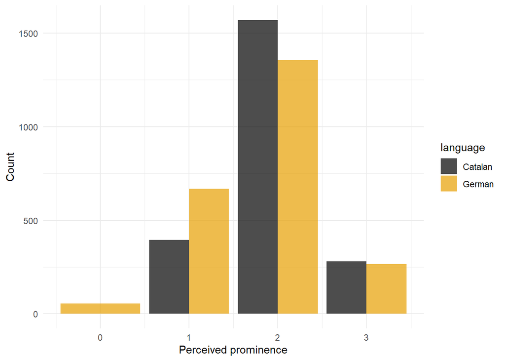

```r
syll_per_pros <-
  targets %>%
  group_by(language, percProm) %>%
  summarize(Count = n()) %>%
  mutate(Proportion = Count / sum(Count))

## Count
ggplot(syll_per_pros, aes(x = percProm, y = Count, fill = language)) +
  geom_bar(stat = "identity", position = "dodge", alpha = 0.7) +
  labs(#title = "Count of Syll per Language and Prominence",
       x = "Perceived prominence", y = "Count") +
  scale_fill_manual(values = colorBlindBlack8) +
  theme_minimal()
```

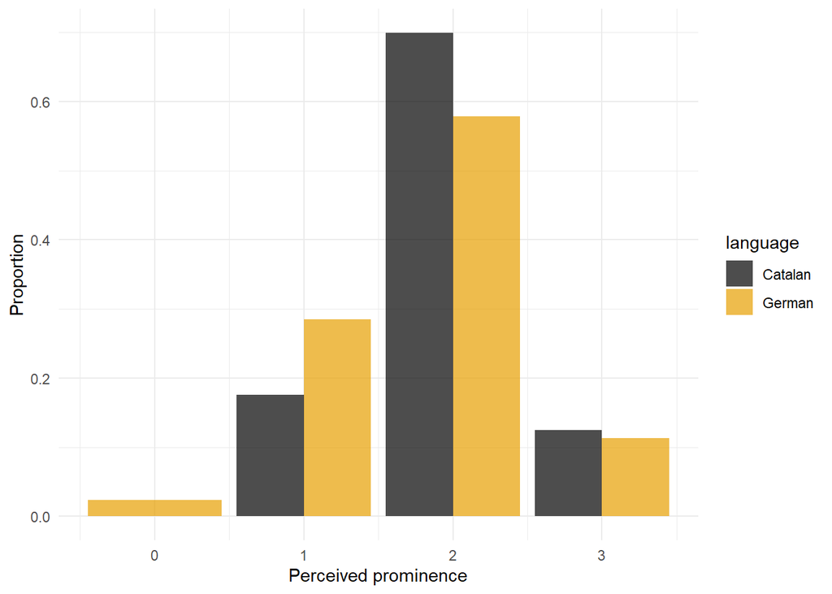

```r
ggsave(filename = paste0(plots, "prominence_count.pdf"), plot = last_plot(), width = 6, height = 4)

## Proportion
ggplot(syll_per_pros, aes(x = percProm, y = Proportion, fill = language)) +
  geom_bar(stat = "identity", position = "dodge", alpha = 0.7) +
  labs(#title = "Proportion of Syll per Language and Prominence",
       x = "Perceived prominence", y = "Proportion") +
  scale_fill_manual(values = colorBlindBlack8) +
  theme_minimal()
```

```r
ggsave(filename = paste0(plots, "prominence_prop.pdf"), plot = last_plot(), width = 6, height = 4)
```

## 3.2 Averages prominence

### 3.2.1 Duration

What is the average duration across the different prosodic prominence ratings in Catalan vs in German?

```r
targets %>%
  group_by(language, percProm) %>%
  summarize(avg_duration = mean(duration, na.rm = TRUE))
```

| language | percProm | avg_duration |
| --- | --- | --- |
| Catalan | 1 | 0.1749165 |
| Catalan | 2 | 0.2000892 |
| Catalan | 3 | 0.2429253 |
| German | 0 | 0.2189643 |
| German | 1 | 0.2438366 |
| German | 2 | 0.2768103 |
| German | 3 | 0.3202481 |

Let’s plot it.

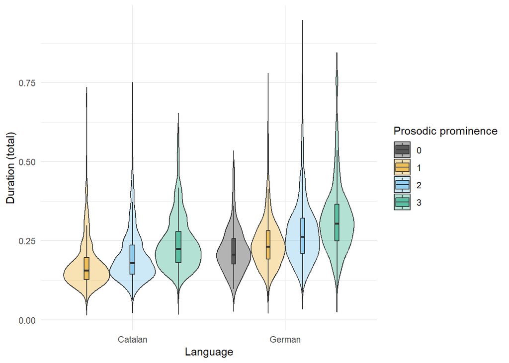

```r
ggplot(targets %>% filter(!is.na(percProm)), aes(x = language, y = duration, fill = as.factor(percProm))) +
  geom_violin(scale = "width", trim = FALSE, alpha = 0.3) +
  geom_boxplot(width = 0.1, outlier.shape = NA, position = position_dodge(width = 0.9), alpha = 0.5) +
  labs(
    #title = "Duration of Prosodic Prominence Ratings by Language",
    x = "Language",
    y = "Duration (total)",
    fill = "Prosodic prominence"
  ) +
  scale_fill_manual(values = colorBlindBlack8) +
  theme_minimal()
```

```r
ggsave(filename = paste0(plots, "prominence_duration.pdf"), plot = last_plot(), width = 6, height = 4)
```

### 3.2.2 Duration without silences

What is the average duration of sounding across the different prosodic prominence ratings in Catalan vs in German?

```r
targets %>%
  group_by(language, percProm) %>%
  summarize(avg_duration_noSilence = mean(duration_noSilence, na.rm = TRUE))
```

| language | percProm | avg_duration_noSilence |
| --- | --- | --- |
| Catalan | 1 | 0.1647462 |
| Catalan | 2 | 0.1862293 |
| Catalan | 3 | 0.2280249 |
| German | 0 | 0.2100000 |
| German | 1 | 0.2331109 |
| German | 2 | 0.2636125 |
| German | 3 | 0.3010150 |

Let’s plot it.

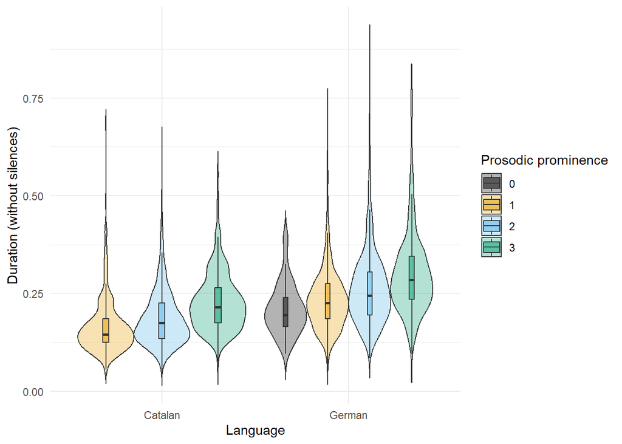

```r
ggplot(targets %>% filter(!is.na(percProm)), aes(x = language, y = duration_noSilence, fill = as.factor(percProm))) +
  geom_violin(scale = "width", trim = FALSE, alpha = 0.3) +
  geom_boxplot(width = 0.1, outlier.shape = NA, position = position_dodge(width = 0.9), alpha = 0.5) +
  labs(
    #title = "Duration of Prosodic Prominence Ratings by Language",
    x = "Language",
    y = "Duration (without silences)",
    fill = "Prosodic prominence"
  ) +
  scale_fill_manual(values = colorBlindBlack8) +
  theme_minimal()
```

```r
ggsave(filename = paste0(plots, "prominence_duration_noSilence.pdf"), plot = last_plot(), width = 6, height = 4)
```

### 3.2.3 Amplitude (median)

What is the average amplitude (median) across the different prosodic prominence ratings in Catalan vs in German?

```r
targets %>%
  group_by(language, percProm) %>%
  summarize(avg_ampl_median = mean(ampl_median, na.rm = TRUE))
```

| language | percProm | avg_ampl_median |
| --- | --- | --- |
| Catalan | 1 | 0.10719074 |
| Catalan | 2 | 0.13447140 |
| Catalan | 3 | 0.11814134 |
| German | 0 | 0.01554430 |
| German | 1 | 0.02659406 |
| German | 2 | 0.03274203 |
| German | 3 | 0.04664022 |

Let’s plot it.

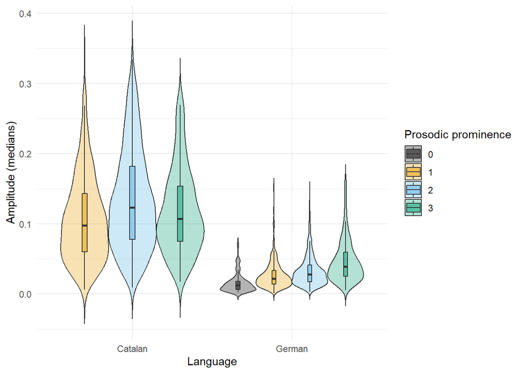

```r
ggplot(targets %>% filter(!is.na(percProm)), aes(x = language, y = ampl_median, fill = as.factor(percProm))) +
  geom_violin(scale = "width", trim = FALSE, alpha = 0.3) +
  geom_boxplot(width = 0.1, outlier.shape = NA, position = position_dodge(width = 0.9), alpha = 0.5) +
  labs(
    #title = "Duration of Prosodic Prominence Ratings by Language",
    x = "Language",
    y = "Amplitude (medians)",
    fill = "Prosodic prominence"
  ) +
  scale_fill_manual(values = colorBlindBlack8) +
  theme_minimal()
```

```r
ggsave(filename = paste0(plots, "prominence_ampl_median.pdf"), plot = last_plot(), width = 6, height = 4)
```

### 3.2.4 Amplitude (median) without silences

What is the average amplitude (median) without silences across the different prosodic prominence ratings in Catalan vs in German?

```r
targets %>%
  group_by(language, percProm) %>%
  summarize(avg_ampl_noSilence_median = mean(ampl_noSilence_median, na.rm = TRUE))
```

| language | percProm | avg_ampl_noSilence_median |
| --- | --- | --- |
| Catalan | 1 | 0.11028949 |
| Catalan | 2 | 0.14051945 |
| Catalan | 3 | 0.12444611 |
| German | 0 | 0.01583677 |
| German | 1 | 0.02757996 |
| German | 2 | 0.03471111 |
| German | 3 | 0.05012385 |

Let’s plot it.

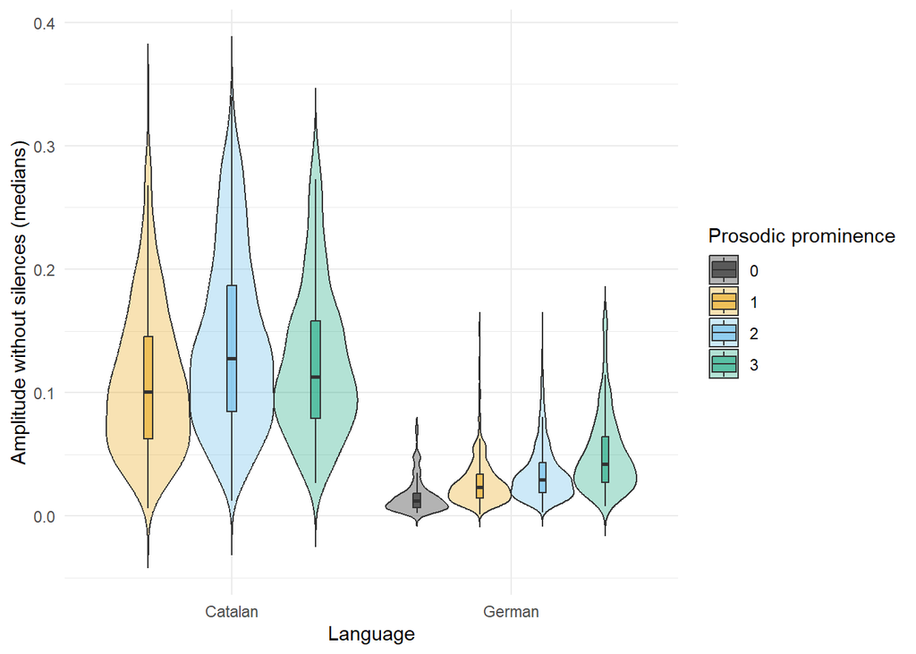

```r
ggplot(targets %>% filter(!is.na(percProm)), aes(x = language, y = ampl_noSilence_median, fill = as.factor(percProm))) +
  geom_violin(scale = "width", trim = FALSE, alpha = 0.3) +
  geom_boxplot(width = 0.1, outlier.shape = NA, position = position_dodge(width = 0.9), alpha = 0.5) +
  labs(
    #title = "Duration of Prosodic Prominence Ratings by Language",
    x = "Language",
    y = "Amplitude without silences (medians)",
    fill = "Prosodic prominence"
  ) +
  scale_fill_manual(values = colorBlindBlack8) +
  theme_minimal()
```

```r
ggsave(filename = paste0(plots, "prominence_ampl_noSilence_median.pdf"), plot = last_plot(), width = 6, height = 4)
```

### 3.2.5 Amplitude envelope slope

What is the average amplitude envelope slope across the different prosodic prominence ratings in Catalan vs in German?

```r
targets %>%
  group_by(language, percProm) %>%
  summarize(avg_env_slope = mean(env_slope, na.rm = TRUE))
```

| language | percProm | avg_env_slope |
| --- | --- | --- |
| Catalan | 1 | 3.489631e-05 |
| Catalan | 2 | 1.836514e-04 |
| Catalan | 3 | 2.683369e-04 |
| German | 0 | -4.623464e-05 |
| German | 1 | 3.508691e-05 |
| German | 2 | 9.698175e-05 |
| German | 3 | 1.695211e-04 |

Let’s plot it.

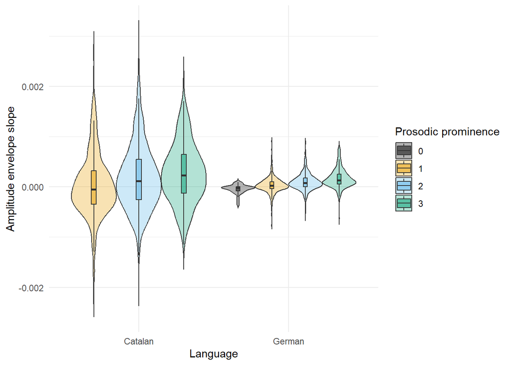

```r
ggplot(targets %>% filter(!is.na(percProm)), aes(x = language, y = env_slope, fill = as.factor(percProm))) +
  geom_violin(scale = "width", trim = FALSE, alpha = 0.3) +
  geom_boxplot(width = 0.1, outlier.shape = NA, position = position_dodge(width = 0.9), alpha = 0.5) +
  labs(
    #title = "Duration of Prosodic Prominence Ratings by Language",
    x = "Language",
    y = "Amplitude envelope slope",
    fill = "Prosodic prominence"
  ) +
  scale_fill_manual(values = colorBlindBlack8) +
  theme_minimal()
```

```r
ggsave(filename = paste0(plots, "prominence_env_slope.pdf"), plot = last_plot(), width = 6, height = 4)
```

### 3.2.6 Pitch (median)

What is the average pitch (median) across the different prosodic prominence ratings in Catalan vs in German?

```r
# Raw
targets %>%
  group_by(language, percProm) %>%
  summarize(avg_pitch_median = mean(pitch_median, na.rm = TRUE))
```

| language | percProm | avg_pitch_median |
| --- | --- | --- |
| Catalan | 1 | 202.1921 |
| Catalan | 2 | 211.5306 |
| Catalan | 3 | 221.6594 |
| German | 0 | 200.9196 |
| German | 1 | 180.7404 |
| German | 2 | 190.5628 |
| German | 3 | 197.1554 |

```r
# Normalized
targets %>%
  group_by(language, percProm) %>%
  summarize(avg_pitch_median = mean(pitch_median_norm, na.rm = TRUE))
```

| language | percProm | avg_pitch_median |
| --- | --- | --- |
| Catalan | 1 | -0.19762899 |
| Catalan | 2 | -0.07007813 |
| Catalan | 3 | -0.05754886 |
| German | 0 | -0.22382723 |
| German | 1 | -0.33085573 |
| German | 2 | 0.05032744 |
| German | 3 | 0.38792513 |

Let’s plot it.

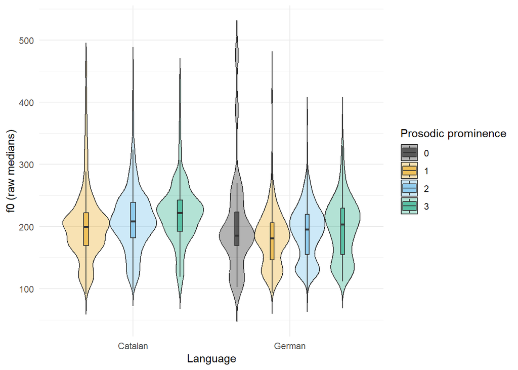

```r
# Raw
ggplot(targets %>% filter(!is.na(percProm)), aes(x = language, y = pitch_median, fill = as.factor(percProm))) +
  geom_violin(scale = "width", trim = FALSE, alpha = 0.3) +
  geom_boxplot(width = 0.1, outlier.shape = NA, position = position_dodge(width = 0.9), alpha = 0.5) +
  labs(
    #title = "Duration of Prosodic Prominence Ratings by Language",
    x = "Language",
    y = "f0 (raw medians)",
    fill = "Prosodic prominence"
  ) +
  scale_fill_manual(values = colorBlindBlack8) +
  theme_minimal()
```

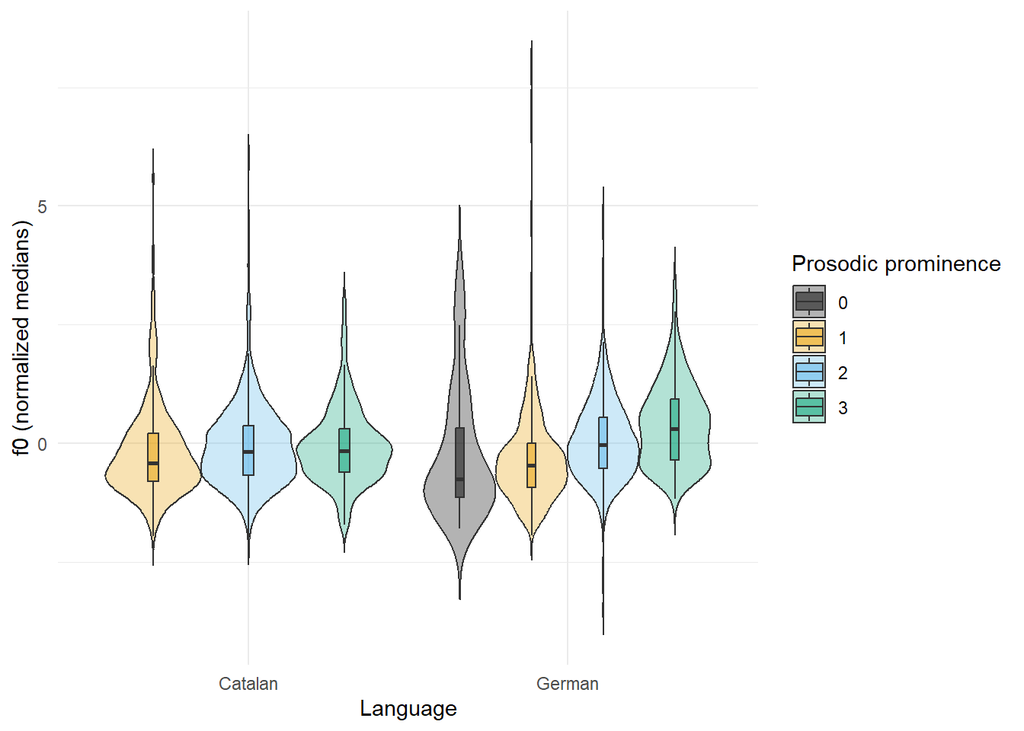

```r
ggsave(filename = paste0(plots, "prominence_pitch_median_raw.pdf"), plot = last_plot(), width = 6, height = 4)

# Normalized
ggplot(targets %>% filter(!is.na(percProm)), aes(x = language, y = pitch_median_norm, fill = as.factor(percProm))) +
  geom_violin(scale = "width", trim = FALSE, alpha = 0.3) +
  geom_boxplot(width = 0.1, outlier.shape = NA, position = position_dodge(width = 0.9), alpha = 0.5) +
  labs(
    #title = "Duration of Prosodic Prominence Ratings by Language",
    x = "Language",
    y = "f0 (normalized medians)",
    fill = "Prosodic prominence"
  ) +
  scale_fill_manual(values = colorBlindBlack8) +
  theme_minimal()
```

```r
ggsave(filename = paste0(plots, "prominence_pitch_median_norm.pdf"), plot = last_plot(), width = 6, height = 4)
```

### 3.2.7 Pitch (sd)

What is the average pitch (sd) across the different prosodic prominence ratings in Catalan vs in German?

```r
# Raw
targets %>%
  group_by(language, percProm) %>%
  summarize(avg_pitch_sd = mean(pitch_sd, na.rm = TRUE))
```

| language | percProm | avg_pitch_sd |
| --- | --- | --- |
| Catalan | 1 | 10.57754 |
| Catalan | 2 | 13.99336 |
| Catalan | 3 | 18.30875 |
| German | 0 | 11.52081 |
| German | 1 | 10.87019 |
| German | 2 | 14.72510 |
| German | 3 | 20.15240 |

```r
# Normalized
targets %>%
  group_by(language, percProm) %>%
  summarize(avg_pitch_sd = mean(pitch_sd_norm, na.rm = TRUE))
```

| language | percProm | avg_pitch_sd |
| --- | --- | --- |
| Catalan | 1 | -0.15333339 |
| Catalan | 2 | 0.02739033 |
| Catalan | 3 | 0.06302831 |
| German | 0 | -0.21973001 |
| German | 1 | -0.13506845 |
| German | 2 | 0.24883996 |
| German | 3 | 0.58178341 |

Let’s plot it.

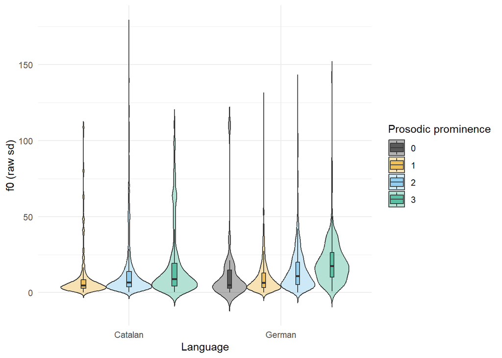

```r
# Raw
ggplot(targets %>% filter(!is.na(percProm)), aes(x = language, y = pitch_sd, fill = as.factor(percProm))) +
  geom_violin(scale = "width", trim = FALSE, alpha = 0.3) +
  geom_boxplot(width = 0.1, outlier.shape = NA, position = position_dodge(width = 0.9), alpha = 0.5) +
  labs(
    #title = "Duration of Prosodic Prominence Ratings by Language",
    x = "Language",
    y = "f0 (raw sd)",
    fill = "Prosodic prominence"
  ) +
  scale_fill_manual(values = colorBlindBlack8) +
  theme_minimal()
```

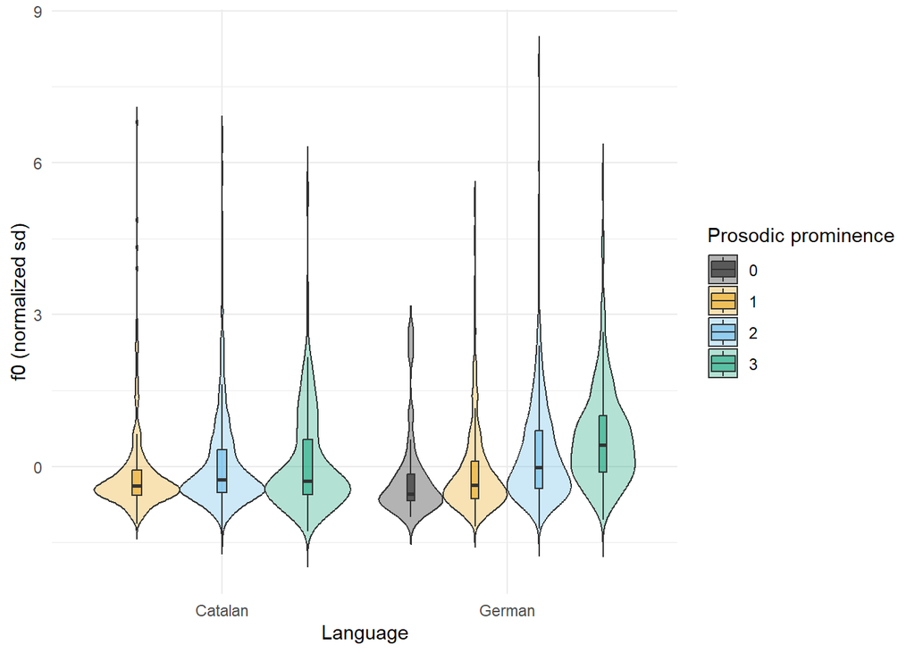

```r
ggsave(filename = paste0(plots, "prominence_pitch_sd_raw.pdf"), plot = last_plot(), width = 6, height = 4)

# Normalized
ggplot(targets %>% filter(!is.na(percProm)), aes(x = language, y = pitch_sd_norm, fill = as.factor(percProm))) +
  geom_violin(scale = "width", trim = FALSE, alpha = 0.3) +
  geom_boxplot(width = 0.1, outlier.shape = NA, position = position_dodge(width = 0.9), alpha = 0.5) +
  labs(
    #title = "Duration of Prosodic Prominence Ratings by Language",
    x = "Language",
    y = "f0 (normalized sd)",
    fill = "Prosodic prominence"
  ) +
  scale_fill_manual(values = colorBlindBlack8) +
  theme_minimal()
```

```r
ggsave(filename = paste0(plots, "prominence_pitch_sd_norm.pdf"), plot = last_plot(), width = 6, height = 4)
```

### 3.2.8 F0 slope

What is the average f0 slope across the different prosodic prominence ratings in Catalan vs in German?

```r
# Raw
targets %>%
  group_by(language, percProm) %>%
  summarize(avg_f0_slope = mean(f0_slope, na.rm = TRUE))
```

| language | percProm | avg_f0_slope |
| --- | --- | --- |
| Catalan | 1 | -0.058697997 |
| Catalan | 2 | -0.026050232 |
| Catalan | 3 | 0.010751936 |
| German | 0 | -0.107604404 |
| German | 1 | -0.001053306 |
| German | 2 | 0.120979056 |
| German | 3 | 0.198145012 |

```r
# Normalized
targets %>%
  group_by(language, percProm) %>%
  summarize(avg_f0_slope = mean(f0_slope_norm, na.rm = TRUE))
```

| language | percProm | avg_f0_slope |
| --- | --- | --- |
| Catalan | 1 | -0.153465502 |
| Catalan | 2 | -0.057012630 |
| Catalan | 3 | 0.006096762 |
| German | 0 | -0.228381713 |
| German | 1 | 0.090319189 |
| German | 2 | 0.543963468 |
| German | 3 | 0.841043586 |

Let’s plot it.

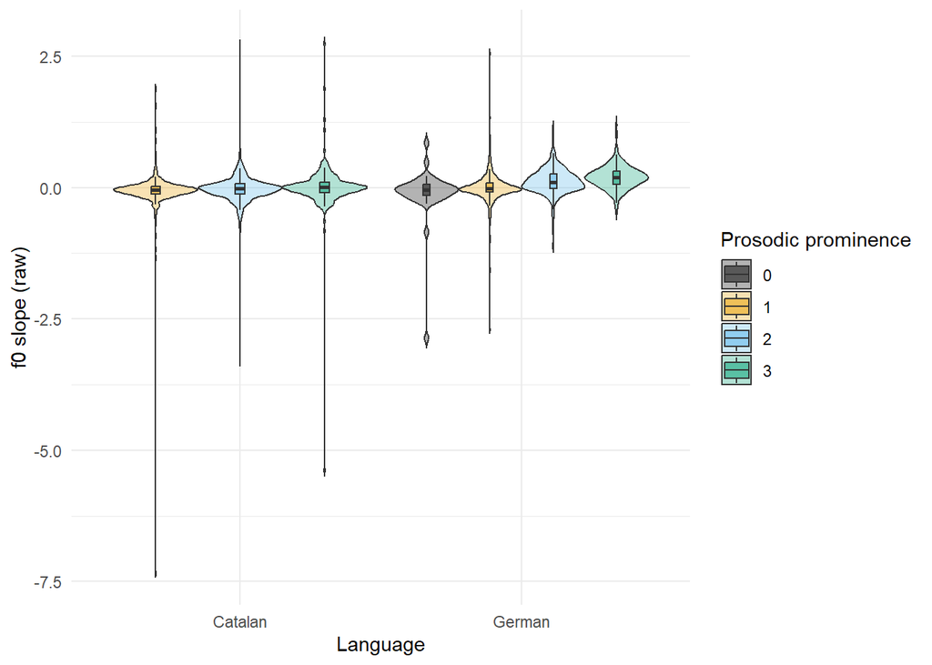

```r
# Raw
ggplot(targets %>% filter(!is.na(percProm)), aes(x = language, y = f0_slope, fill = as.factor(percProm))) +
  geom_violin(scale = "width", trim = FALSE, alpha = 0.3) +
  geom_boxplot(width = 0.1, outlier.shape = NA, position = position_dodge(width = 0.9), alpha = 0.5) +
  labs(
    #title = "Duration of Prosodic Prominence Ratings by Language",
    x = "Language",
    y = "f0 slope (raw)",
    fill = "Prosodic prominence"
  ) +
  scale_fill_manual(values = colorBlindBlack8) +
  theme_minimal()
```

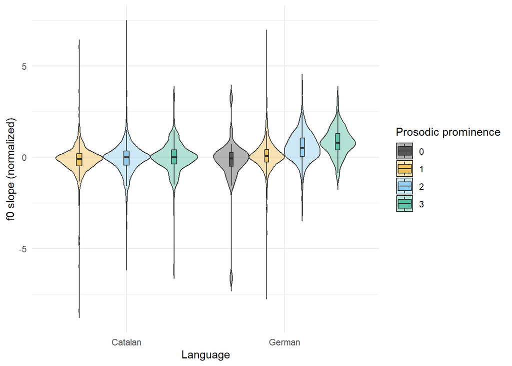

```r
ggsave(filename = paste0(plots, "prominence_f0_slope_raw.pdf"), plot = last_plot(), width = 6, height = 4)

# Normalized
ggplot(targets %>% filter(!is.na(percProm)), aes(x = language, y = f0_slope_norm, fill = as.factor(percProm))) +
  geom_violin(scale = "width", trim = FALSE, alpha = 0.3) +
  geom_boxplot(width = 0.1, outlier.shape = NA, position = position_dodge(width = 0.9), alpha = 0.5) +
  labs(
    #title = "Duration of Prosodic Prominence Ratings by Language",
    x = "Language",
    y = "f0 slope (normalized)",
    fill = "Prosodic prominence"
  ) +
  scale_fill_manual(values = colorBlindBlack8) +
  theme_minimal()
```

```r
ggsave(filename = paste0(plots, "prominence_f0_slope_norm.pdf"), plot = last_plot(), width = 6, height = 4)
```

### 3.2.9 F1 (median)

What is the average f1 (median) across the different prosodic prominence ratings in Catalan vs in German?

```r
# Raw
targets %>%
  group_by(language, percProm) %>%
  summarize(avg_f1_freq_median = mean(f1_freq_median, na.rm = TRUE))
```

| language | percProm | avg_f1_freq_median |
| --- | --- | --- |
| Catalan | 1 | 530.2646 |
| Catalan | 2 | 556.1507 |
| Catalan | 3 | 542.9448 |
| German | 0 | 545.7876 |
| German | 1 | 541.0454 |
| German | 2 | 520.3339 |
| German | 3 | 416.4133 |

```r
# Normalized
targets %>%
  group_by(language, percProm) %>%
  summarize(avg_f1_freq_median = mean(f1_freq_median_norm, na.rm = TRUE))
```

| language | percProm | avg_f1_freq_median |
| --- | --- | --- |
| Catalan | 1 | -0.36912773 |
| Catalan | 2 | -0.23704095 |
| Catalan | 3 | -0.24914123 |
| German | 0 | 0.29098508 |
| German | 1 | 0.19998025 |
| German | 2 | 0.06146468 |
| German | 3 | -0.54617920 |

Let’s plot it.

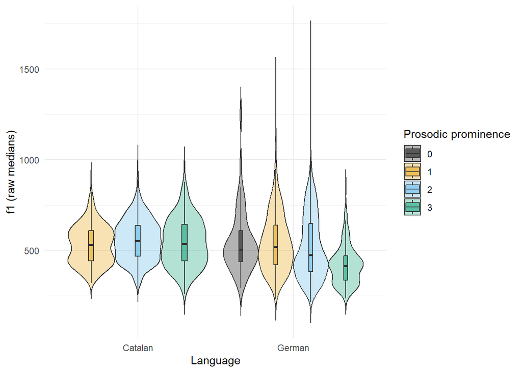

```r
# Raw
ggplot(targets %>% filter(!is.na(percProm)), aes(x = language, y = f1_freq_median, fill = as.factor(percProm))) +
  geom_violin(scale = "width", trim = FALSE, alpha = 0.3) +
  geom_boxplot(width = 0.1, outlier.shape = NA, position = position_dodge(width = 0.9), alpha = 0.5) +
  labs(
    #title = "Duration of Prosodic Prominence Ratings by Language",
    x = "Language",
    y = "f1 (raw medians)",
    fill = "Prosodic prominence"
  ) +
  scale_fill_manual(values = colorBlindBlack8) +
  theme_minimal()
```

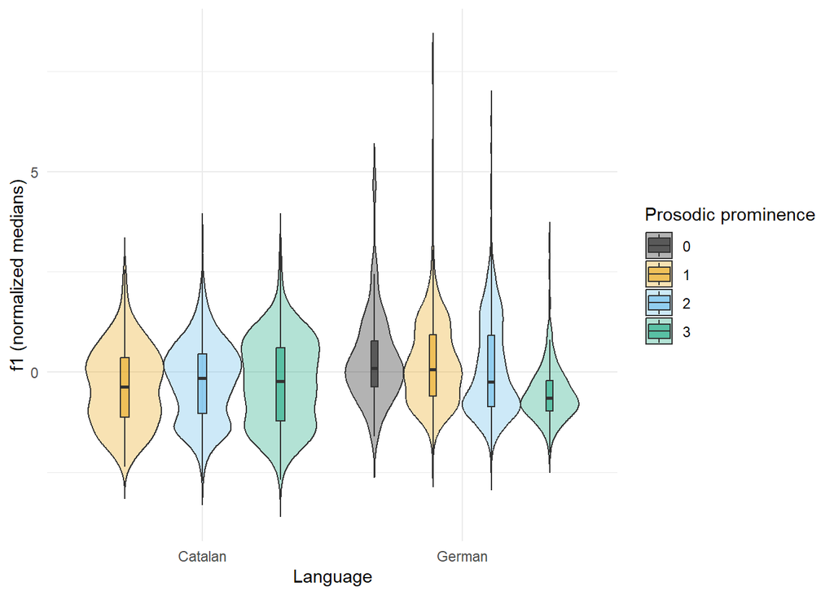

```r
ggsave(filename = paste0(plots, "prominence_f1_freq_median_raw.pdf"), plot = last_plot(), width = 6, height = 4)

# Normalized
ggplot(targets %>% filter(!is.na(percProm)), aes(x = language, y = f1_freq_median_norm, fill = as.factor(percProm))) +
  geom_violin(scale = "width", trim = FALSE, alpha = 0.3) +
  geom_boxplot(width = 0.1, outlier.shape = NA, position = position_dodge(width = 0.9), alpha = 0.5) +
  labs(
    #title = "Duration of Prosodic Prominence Ratings by Language",
    x = "Language",
    y = "f1 (normalized medians)",
    fill = "Prosodic prominence"
  ) +
  scale_fill_manual(values = colorBlindBlack8) +
  theme_minimal()
```

```r
ggsave(filename = paste0(plots, "prominence_f1_freq_median_norm.pdf"), plot = last_plot(), width = 6, height = 4)
```

We will not use f1 because we cannot be sure that the distribution of vowels is even across perceived prominence ratings.

### 3.2.10 F2 (median)

What is the average f2 (median) across the different prosodic prominence ratings in Catalan vs in German?

```r
# Raw
targets %>%
  group_by(language, percProm) %>%
  summarize(avg_f2_freq_median = mean(f2_freq_median, na.rm = TRUE))
```

| language | percProm | avg_f2_freq_median |
| --- | --- | --- |
| Catalan | 1 | 1650.695 |
| Catalan | 2 | 1643.903 |
| Catalan | 3 | 1823.191 |
| German | 0 | 1653.472 |
| German | 1 | 1666.730 |
| German | 2 | 1743.939 |
| German | 3 | 1863.279 |

```r
# Normalized
targets %>%
  group_by(language, percProm) %>%
  summarize(avg_f2_freq_median = mean(f2_freq_median_norm, na.rm = TRUE))
```

| language | percProm | avg_f2_freq_median |
| --- | --- | --- |
| Catalan | 1 | 0.21717241 |
| Catalan | 2 | 0.19102134 |
| Catalan | 3 | 0.58960532 |
| German | 0 | -0.13263161 |
| German | 1 | -0.12319437 |
| German | 2 | 0.04491558 |
| German | 3 | 0.37763639 |

Let’s plot it.

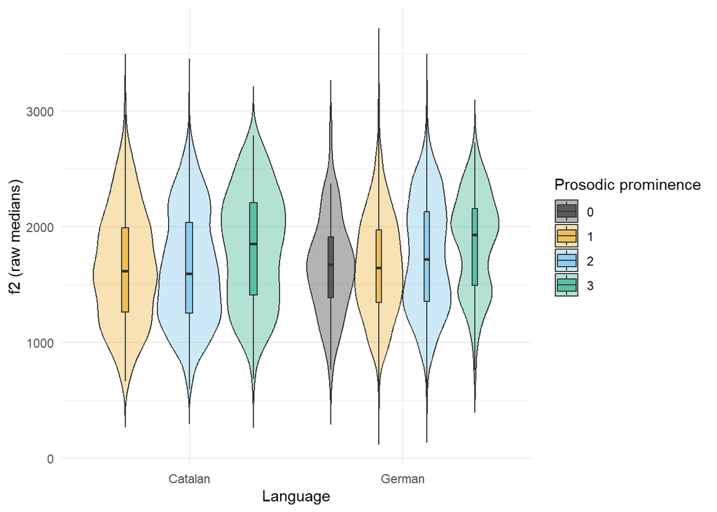

```r
# Raw
ggplot(targets %>% filter(!is.na(percProm)), aes(x = language, y = f2_freq_median, fill = as.factor(percProm))) +
  geom_violin(scale = "width", trim = FALSE, alpha = 0.3) +
  geom_boxplot(width = 0.1, outlier.shape = NA, position = position_dodge(width = 0.9), alpha = 0.5) +
  labs(
    #title = "Duration of Prosodic Prominence Ratings by Language",
    x = "Language",
    y = "f2 (raw medians)",
    fill = "Prosodic prominence"
  ) +
  scale_fill_manual(values = colorBlindBlack8) +
  theme_minimal()
```

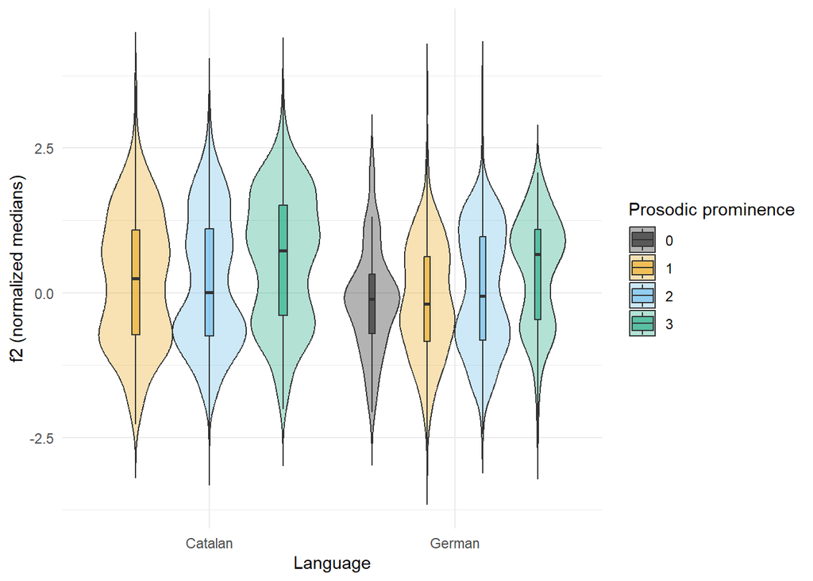

```r
ggsave(filename = paste0(plots, "prominence_f2_freq_median_raw.pdf"), plot = last_plot(), width = 6, height = 4)

# Normalized
ggplot(targets %>% filter(!is.na(percProm)), aes(x = language, y = f2_freq_median_norm, fill = as.factor(percProm))) +
  geom_violin(scale = "width", trim = FALSE, alpha = 0.3) +
  geom_boxplot(width = 0.1, outlier.shape = NA, position = position_dodge(width = 0.9), alpha = 0.5) +
  labs(
    #title = "Duration of Prosodic Prominence Ratings by Language",
    x = "Language",
    y = "f2 (normalized medians)",
    fill = "Prosodic prominence"
  ) +
  scale_fill_manual(values = colorBlindBlack8) +
  theme_minimal()
```

```r
ggsave(filename = paste0(plots, "prominence_f2_freq_median_norm.pdf"), plot = last_plot(), width = 6, height = 4)
```

We will not use f2 because we cannot be sure that the distribution of vowels is even across perceived prominence ratings.

### 3.2.11 Spectral centroid (median)

What is the average spectral centeroid (median) across the different prosodic prominence ratings in Catalan vs in German?

```r
targets %>%
  group_by(language, percProm) %>%
  summarize(avg_specCentroid_median = mean(specCentroid_median, na.rm = TRUE))
```

| language | percProm | avg_specCentroid_median |
| --- | --- | --- |
| Catalan | 1 | 317.7988 |
| Catalan | 2 | 317.6634 |
| Catalan | 3 | 309.8666 |
| German | 0 | 279.7627 |
| German | 1 | 286.2358 |
| German | 2 | 285.5585 |
| German | 3 | 287.8506 |

Let’s plot it.

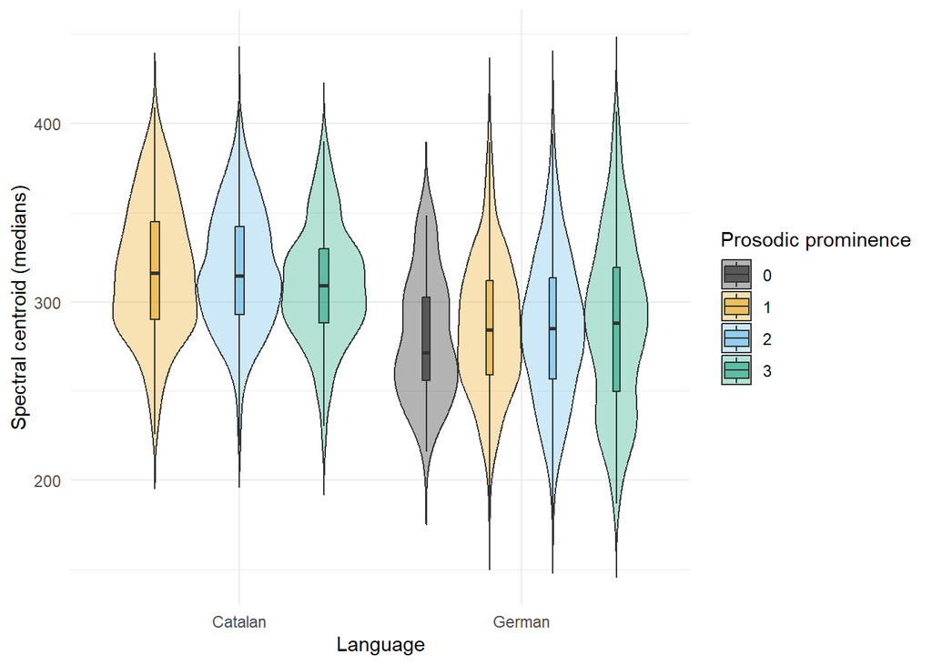

```r
ggplot(targets %>% filter(!is.na(percProm)), aes(x = language, y = specCentroid_median, fill = as.factor(percProm))) +
  geom_violin(scale = "width", trim = FALSE, alpha = 0.3) +
  geom_boxplot(width = 0.1, outlier.shape = NA, position = position_dodge(width = 0.9), alpha = 0.5) +
  labs(
    #title = "Duration of Prosodic Prominence Ratings by Language",
    x = "Language",
    y = "Spectral centroid (medians)",
    fill = "Prosodic prominence"
  ) +
  scale_fill_manual(values = colorBlindBlack8) +
  theme_minimal()
```

```r
ggsave(filename = paste0(plots, "prominence_specCentroid_median.pdf"), plot = last_plot(), width = 6, height = 4)
```

### 3.2.12 Entropy (median)

What is the average entropy (median) across the different prosodic prominence ratings in Catalan vs in German?

```r
targets %>%
  group_by(language, percProm) %>%
  summarize(avg_entropy_median = mean(entropy_median, na.rm = TRUE))
```

| language | percProm | avg_entropy_median |
| --- | --- | --- |
| Catalan | 1 | 0.4264968 |
| Catalan | 2 | 0.3854849 |
| Catalan | 3 | 0.3735193 |
| German | 0 | 0.5094277 |
| German | 1 | 0.4550654 |
| German | 2 | 0.4001210 |
| German | 3 | 0.3795897 |

Let’s plot it.

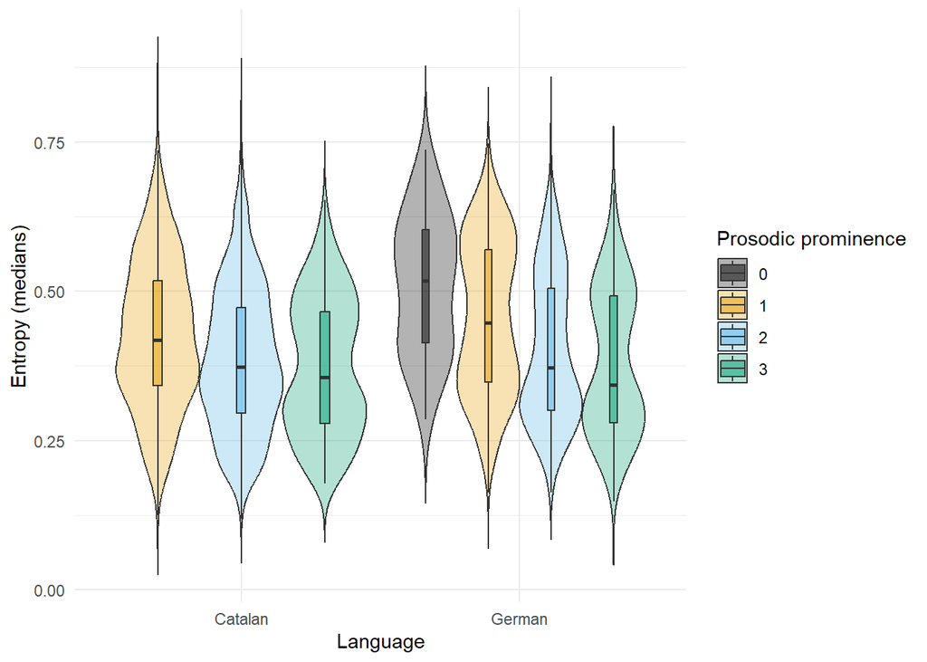

```r
ggplot(targets %>% filter(!is.na(percProm)), aes(x = language, y = entropy_median, fill = as.factor(percProm))) +
  geom_violin(scale = "width", trim = FALSE, alpha = 0.3) +
  geom_boxplot(width = 0.1, outlier.shape = NA, position = position_dodge(width = 0.9), alpha = 0.5) +
  labs(
    #title = "Duration of Prosodic Prominence Ratings by Language",
    x = "Language",
    y = "Entropy (medians)",
    fill = "Prosodic prominence"
  ) +
  scale_fill_manual(values = colorBlindBlack8) +
  theme_minimal()
```

```r
ggsave(filename = paste0(plots, "prominence_entropy_median.pdf"), plot = last_plot(), width = 6, height = 4)
```

### 3.2.13 Harmonics-to-Noise Ratio (median)

What is the average Harmonics-to-Noise Ratio (median) across the different prosodic prominence ratings in Catalan vs in German?

```r
targets %>%
  group_by(language, percProm) %>%
  summarize(avg_HNR_median = mean(HNR_median, na.rm = TRUE))
```

| language | percProm | avg_HNR_median |
| --- | --- | --- |
| Catalan | 1 | 10.465289 |
| Catalan | 2 | 11.219171 |
| Catalan | 3 | 11.228677 |
| German | 0 | 6.824782 |
| German | 1 | 8.656387 |
| German | 2 | 9.784216 |
| German | 3 | 10.677856 |

Let’s plot it.

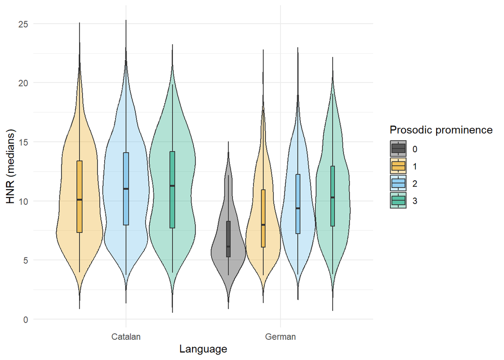

```r
ggplot(targets %>% filter(!is.na(percProm)), aes(x = language, y = HNR_median, fill = as.factor(percProm))) +
  geom_violin(scale = "width", trim = FALSE, alpha = 0.3) +
  geom_boxplot(width = 0.1, outlier.shape = NA, position = position_dodge(width = 0.9), alpha = 0.5) +
  labs(
    #title = "Duration of Prosodic Prominence Ratings by Language",
    x = "Language",
    y = "HNR (medians)",
    fill = "Prosodic prominence"
  ) +
  scale_fill_manual(values = colorBlindBlack8) +
  theme_minimal()
```

```r
ggsave(filename = paste0(plots, "prominence_HNR_median.pdf"), plot = last_plot(), width = 6, height = 4)
```

### 3.2.14 Amplitude modulation (median)

What is the average amplitude modulation (median) across the different prosodic prominence ratings in Catalan vs in German?

```r
targets %>%
  group_by(language, percProm) %>%
  summarize(avg_amEnvDep_median = mean(amEnvDep_median, na.rm = TRUE))
```

| language | percProm | avg_amEnvDep_median |
| --- | --- | --- |
| Catalan | 1 | 0.8505277 |
| Catalan | 2 | 0.7641722 |
| Catalan | 3 | 0.5879588 |
| German | 0 | 0.6337345 |
| German | 1 | 0.5506258 |
| German | 2 | 0.4617880 |
| German | 3 | 0.3569398 |

Let’s plot it.

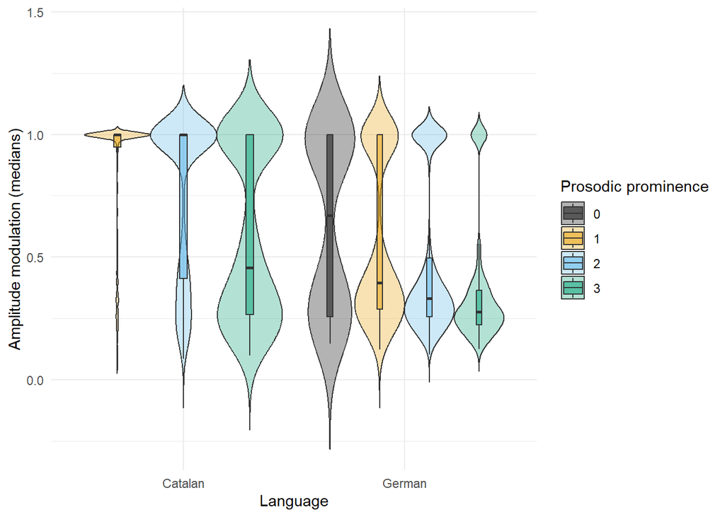

```r
ggplot(targets %>% filter(!is.na(percProm)), aes(x = language, y = amEnvDep_median, fill = as.factor(percProm))) +
  geom_violin(scale = "width", trim = FALSE, alpha = 0.3) +
  geom_boxplot(width = 0.1, outlier.shape = NA, position = position_dodge(width = 0.9), alpha = 0.5) +
  labs(
    #title = "Duration of Prosodic Prominence Ratings by Language",
    x = "Language",
    y = "Amplitude modulation (medians)",
    fill = "Prosodic prominence"
  ) +
  scale_fill_manual(values = colorBlindBlack8) +
  theme_minimal()
```

```r
ggsave(filename = paste0(plots, "prominence_amEnvDep_median.pdf"), plot = last_plot(), width = 6, height = 4)
```

### 3.2.15 Frequency modulation (median)

What is the average frequency modulation (median) across the different prosodic prominence ratings in Catalan vs in German?

```r
targets %>%
  group_by(language, percProm) %>%
  summarize(avg_fmDep_median = mean(fmDep_median, na.rm = TRUE))
```

| language | percProm | avg_fmDep_median |
| --- | --- | --- |
| Catalan | 1 | 0.3531127 |
| Catalan | 2 | 0.4538440 |
| Catalan | 3 | 0.5409593 |
| German | 0 | 0.3462676 |
| German | 1 | 0.4232622 |
| German | 2 | 0.6356788 |
| German | 3 | 0.8434484 |

Let’s plot it.

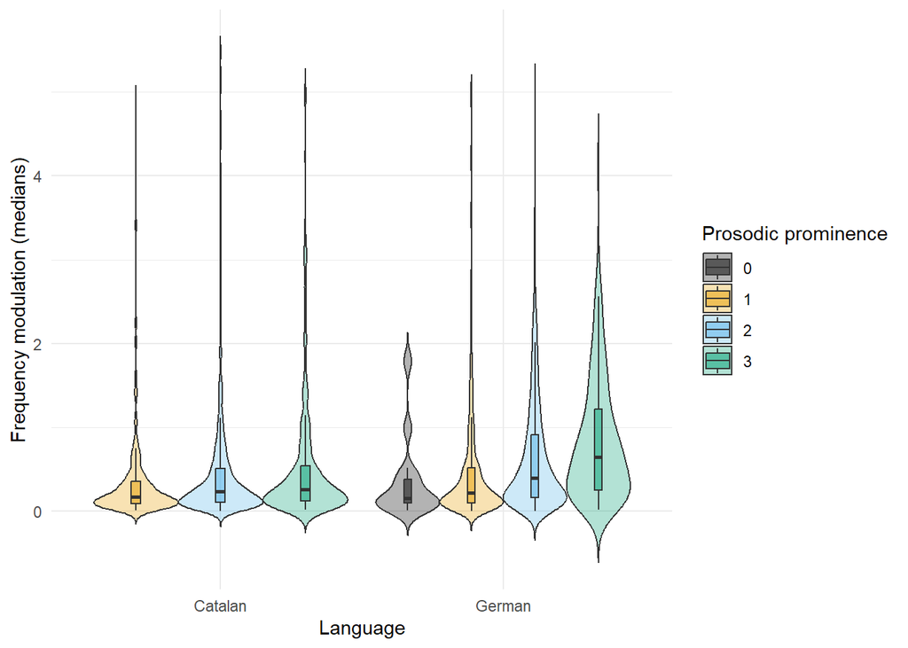

```r
ggplot(targets %>% filter(!is.na(percProm)), aes(x = language, y = fmDep_median, fill = as.factor(percProm))) +
  geom_violin(scale = "width", trim = FALSE, alpha = 0.3) +
  geom_boxplot(width = 0.1, outlier.shape = NA, position = position_dodge(width = 0.9), alpha = 0.5) +
  labs(
    #title = "Duration of Prosodic Prominence Ratings by Language",
    x = "Language",
    y = "Frequency modulation (medians)",
    fill = "Prosodic prominence"
  ) +
  scale_fill_manual(values = colorBlindBlack8) +
  theme_minimal()
```

```r
ggsave(filename = paste0(plots, "prominence_fmDep_median.pdf"), plot = last_plot(), width = 6, height = 4)
```

## 3.3 Pre- and posttonic

Prepare data frame.

work in progress…

```r
data_long <- data_prepost %>%
  select(fileName, language, itemType, focus, annotationNum,
         starts_with("pitch_"), starts_with("env_"), starts_with("duration"),
         starts_with("ampl_"), starts_with("f0_"), starts_with("f1_freq_"),
         starts_with("f2_freq_"), starts_with("specCentroid_"),
         starts_with("entropy_"), starts_with("HNR_"), starts_with("amEnvDep_"),
         starts_with("fmDep_")) %>%
  pivot_longer(cols = -c(fileName, language, itemType, focus, annotationNum),
               names_to = "variable",
               values_to = "value") %>%
  mutate(
    phase = case_when(
      grepl("Pre$", variable) ~ "pre",
      grepl("Post$", variable) ~ "post",
      TRUE ~ "target"
    ),
    # Remove suffixes from variable names for a cleaner look
    variable = gsub("Pre|Post", "", variable)
  )

# Correct the phase factor levels
data_long$phase <- factor(data_long$phase, levels = c("pre", "target", "post"))
```

### 3.3.1 Variable x Language plots

```r
# Get unique languages and variables
languages <- unique(data_long$language)
variables <- unique(data_long$variable)

# Without lines
for (var in variables) {
  for (lang in languages) {
    # Filter data_long for the current language and variable
    data_filtered <- subset(data_long, variable == var & language == lang)

    # Generate the plot for the current language and variable
    p <- ggplot(data = data_filtered, aes(x = phase, y = value, fill = phase)) +
      geom_violin(scale = "width", trim = FALSE, alpha = 0.3) +
      geom_boxplot(width = 0.1, outlier.shape = NA, position = position_dodge(width = 0.9), alpha = 0.5) +
      scale_fill_manual(values = colorBlindBlack8) +
      labs(x = "Syllable",
           y = var,
           title = lang) +
      theme_minimal() +
      theme(legend.position = "none")

    # Dynamically generate the file name to include both language and variable
    file_name <- paste0(plots, "/prepost_", var, "_", lang, ".pdf")

    # Save the plot
    ggsave(filename = file_name, plot = p, width = 10, height = 8)
  }
}

# With lines
for (var in variables) {
  for (lang in languages) {
    # Filter data_long for the current language and variable
    data_filtered <- subset(data_long, variable == var & language == lang)

    # Generate the plot for the current language and variable
    p <- ggplot(data = data_filtered, aes(x = phase, y = value, fill = phase)) +
      geom_violin(scale = "width", trim = FALSE, alpha = 0.3) +
      geom_boxplot(width = 0.1, outlier.shape = NA, position = position_dodge(width = 0.9), alpha = 0.5) +
      geom_line(aes(group = interaction(fileName, annotationNum)), color = "grey", alpha = 0.1) +
      scale_fill_manual(values = colorBlindBlack8) +
      labs(x = "Syllable",
           y = var,
           title = lang) +
      theme_minimal() +
      theme(legend.position = "none")

    # Dynamically generate the file name to include both language and variable
    file_name <- paste0(plots, "/prepost_", var, "_lines_", lang, ".pdf")

    # Save the plot
    ggsave(filename = file_name, plot = p, width = 10, height = 8)
  }
}

# Clean up the environment
rm(languages, lang, variables, var, data_filtered)
```

### 3.3.2 Variables, Language side-by-side

```r
# Define unique variables for plotting
variables <- unique(data_long$variable)

# Without lines
for (var in variables) {
  # Filter df_long for the current variable
  data_filtered <- subset(data_long, variable == var)

  # Generate the plot for the current variable
  p <- ggplot(data = data_filtered, aes(x = phase, y = value, fill = language)) +
    geom_violin(scale = "width", trim = FALSE, alpha = 0.3) +
    geom_boxplot(width = 0.1, outlier.shape = NA, position = position_dodge(width = 0.9), alpha = 0.5) +
    scale_fill_manual(values = colorBlindBlack8) +
    labs(x = "Syllable",
         y = var) +
    theme_minimal()

  # Dynamically generate the file name to include the variable
  file_name <- paste0(plots, "prepost_", var, ".pdf")

  # Save the plot
  ggsave(filename = file_name, plot = p, width = 10, height = 8)
}
# With lines
for (var in variables) {
  # Filter df_long for the current variable
  data_filtered <- subset(data_long, variable == var)

  # Generate the plot for the current variable
  p <- ggplot(data = data_filtered, aes(x = phase, y = value, fill = language)) +
    geom_violin(scale = "width", trim = FALSE, alpha = 0.3) +
    geom_boxplot(width = 0.1, outlier.shape = NA, position = position_dodge(width = 0.9), alpha = 0.5) +
    geom_line(aes(group = interaction(fileName, annotationNum)), color = "grey", alpha = 0.1) +
    scale_fill_manual(values = colorBlindBlack8) +
    labs(x = "Syllable",
         y = var) +
    theme_minimal()

  # Dynamically generate the file name to include the variable
  file_name <- paste0(plots, "prepost_", var, "_lines", ".pdf")

  # Save the plot
  ggsave(filename = file_name, plot = p, width = 10, height = 8)
}
# Clean up
rm(variables, var, data_filtered)
```

### 3.3.3 Pretonic: Averages prominence

#### 3.3.3.1 Duration

What is the average duration of pretonic across the different prosodic prominence ratings in Catalan vs in German?

```r
# Values
data_prepost %>%
  group_by(language, percProm) %>%
  summarize(avg_duration = mean(durationPre, na.rm = TRUE))
```

| language | percProm | avg_duration |
| --- | --- | --- |
| Catalan | 1 | 0.1463031 |
| Catalan | 2 | 0.1595060 |
| Catalan | 3 | 0.1947269 |
| German | 0 | 0.1548148 |
| German | 1 | 0.1922345 |
| German | 2 | 0.2088154 |
| German | 3 | 0.2410076 |

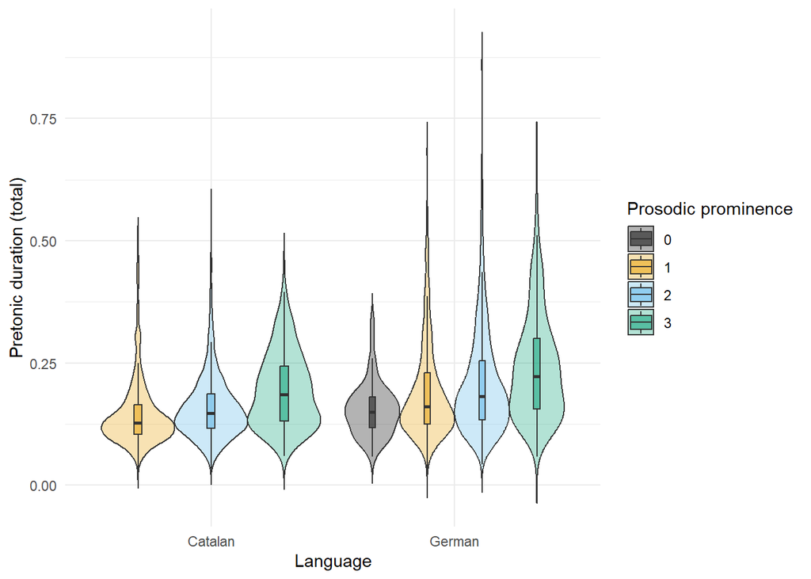

```r
# Plot
ggplot(data_prepost %>% filter(!is.na(percProm)), aes(x = language, y = durationPre, fill = as.factor(percProm))) +
  geom_violin(scale = "width", trim = FALSE, alpha = 0.3) +
  geom_boxplot(width = 0.1, outlier.shape = NA, position = position_dodge(width = 0.9), alpha = 0.5) +
  labs(
    #title = "Duration of Prosodic Prominence Ratings by Language",
    x = "Language",
    y = "Pretonic duration (total)",
    fill = "Prosodic prominence"
  ) +
  scale_fill_manual(values = colorBlindBlack8) +
  theme_minimal()
```

```r
ggsave(filename = paste0(plots, "prominence_duration_pretonic.pdf"), plot = last_plot(), width = 6, height = 4)
```

#### 3.3.3.2 Duration without silences

What is the average duration of sounding across the different prosodic prominence ratings in Catalan vs in German?

```r
# Values
data_prepost %>%
  group_by(language, percProm) %>%
  summarize(avg_duration_noSilence = mean(duration_noSilencePre, na.rm = TRUE))
```

| language | percProm | avg_duration_noSilence |
| --- | --- | --- |
| Catalan | 1 | 0.1380016 |
| Catalan | 2 | 0.1493062 |
| Catalan | 3 | 0.1832329 |
| German | 0 | 0.1485185 |
| German | 1 | 0.1824743 |
| German | 2 | 0.1993999 |
| German | 3 | 0.2278517 |

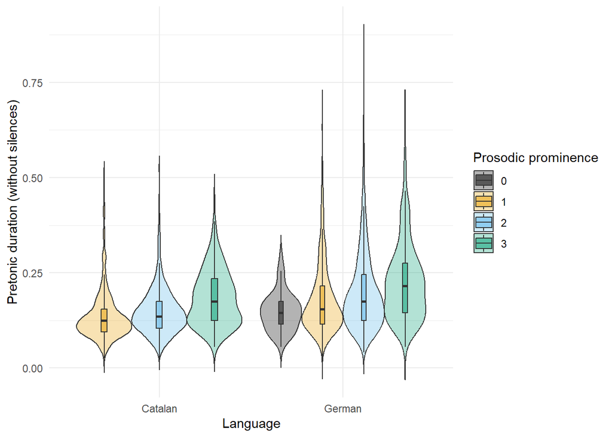

```r
# Plot
ggplot(data_prepost %>% filter(!is.na(percProm)), aes(x = language, y = duration_noSilencePre, fill = as.factor(percProm))) +
  geom_violin(scale = "width", trim = FALSE, alpha = 0.3) +
  geom_boxplot(width = 0.1, outlier.shape = NA, position = position_dodge(width = 0.9), alpha = 0.5) +
  labs(
    #title = "Duration of Prosodic Prominence Ratings by Language",
    x = "Language",
    y = "Pretonic duration (without silences)",
    fill = "Prosodic prominence"
  ) +
  scale_fill_manual(values = colorBlindBlack8) +
  theme_minimal()
```

```r
ggsave(filename = paste0(plots, "prominence_duration_noSilence_pretonic.pdf"), plot = last_plot(), width = 6, height = 4)
```

#### 3.3.3.3 Amplitude (median)

What is the average amplitude (median) across the different prosodic prominence ratings in Catalan vs in German?

```r
# Values
data_prepost %>%
  group_by(language, percProm) %>%
  summarize(avg_ampl_median = mean(ampl_medianPre, na.rm = TRUE))
```

| language | percProm | avg_ampl_median |
| --- | --- | --- |
| Catalan | 1 | 0.12408105 |
| Catalan | 2 | 0.14468686 |
| Catalan | 3 | 0.14174364 |
| German | 0 | 0.03014909 |
| German | 1 | 0.03051320 |
| German | 2 | 0.02923355 |
| German | 3 | 0.02760860 |

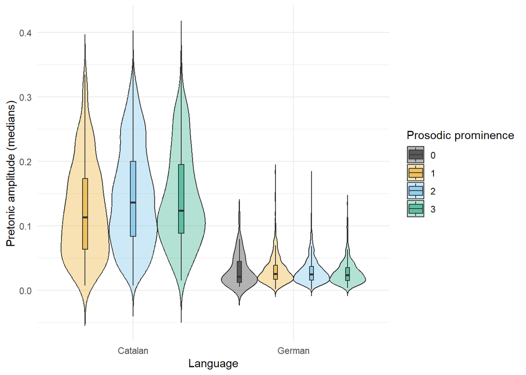

```r
# Plot
ggplot(data_prepost %>% filter(!is.na(percProm)), aes(x = language, y = ampl_medianPre, fill = as.factor(percProm))) +
  geom_violin(scale = "width", trim = FALSE, alpha = 0.3) +
  geom_boxplot(width = 0.1, outlier.shape = NA, position = position_dodge(width = 0.9), alpha = 0.5) +
  labs(
    #title = "Duration of Prosodic Prominence Ratings by Language",
    x = "Language",
    y = "Pretonic amplitude (medians)",
    fill = "Prosodic prominence"
  ) +
  scale_fill_manual(values = colorBlindBlack8) +
  theme_minimal()
```

```r
ggsave(filename = paste0(plots, "prominence_ampl_median_pretonic.pdf"), plot = last_plot(), width = 6, height = 4)
```

#### 3.3.3.4 Amplitude (median) without silences

What is the average amplitude (median) without silences across the different prosodic prominence ratings in Catalan vs in German?

```r
# Values
data_prepost %>%
  group_by(language, percProm) %>%
  summarize(avg_ampl_noSilence_median = mean(ampl_noSilence_medianPre, na.rm = TRUE))
```

| language | percProm | avg_ampl_noSilence_median |
| --- | --- | --- |
| Catalan | 1 | 0.12793292 |
| Catalan | 2 | 0.14993256 |
| Catalan | 3 | 0.14484222 |
| German | 0 | 0.03026716 |
| German | 1 | 0.03094423 |
| German | 2 | 0.02962597 |
| German | 3 | 0.02846353 |

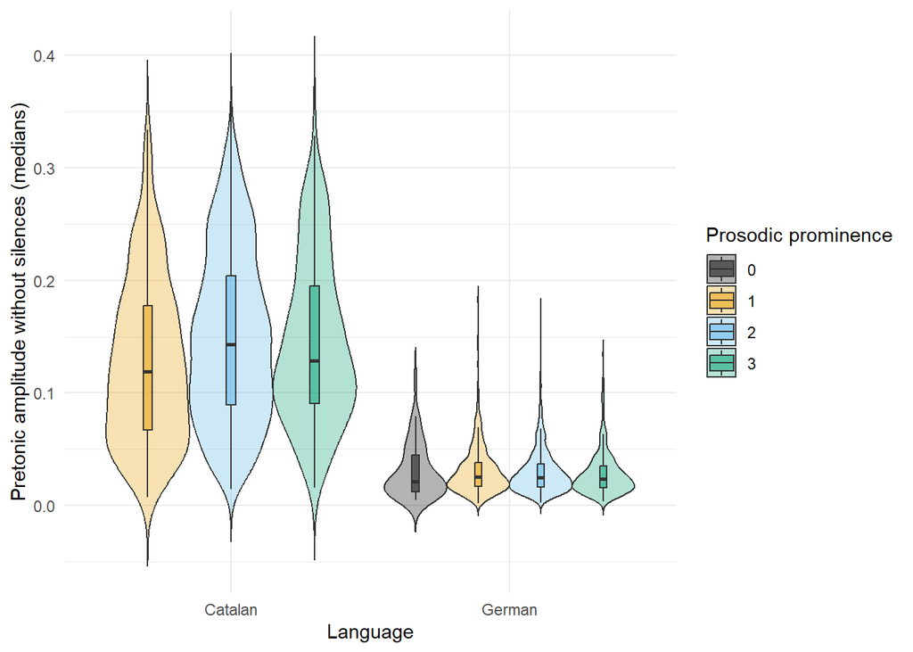

```r
# Plot
ggplot(data_prepost %>% filter(!is.na(percProm)), aes(x = language, y = ampl_noSilence_medianPre, fill = as.factor(percProm))) +
  geom_violin(scale = "width", trim = FALSE, alpha = 0.3) +
  geom_boxplot(width = 0.1, outlier.shape = NA, position = position_dodge(width = 0.9), alpha = 0.5) +
  labs(
    #title = "Duration of Prosodic Prominence Ratings by Language",
    x = "Language",
    y = "Pretonic amplitude without silences (medians)",
    fill = "Prosodic prominence"
  ) +
  scale_fill_manual(values = colorBlindBlack8) +
  theme_minimal()
```

```r
ggsave(filename = paste0(plots, "prominence_ampl_noSilence_median_pretonic.pdf"), plot = last_plot(), width = 6, height = 4)
```

#### 3.3.3.5 Amplitude envelope slope

What is the average amplitude envelope slope across the different prosodic prominence ratings in Catalan vs in German?

```r
# Values
data_prepost %>%
  group_by(language, percProm) %>%
  summarize(avg_env_slope = mean(env_slopePre, na.rm = TRUE))
```

| language | percProm | avg_env_slope |
| --- | --- | --- |
| Catalan | 1 | 2.285964e-04 |
| Catalan | 2 | 1.821722e-04 |
| Catalan | 3 | 2.634226e-04 |
| German | 0 | -1.430030e-04 |
| German | 1 | -1.148835e-04 |
| German | 2 | -7.446924e-05 |
| German | 3 | -4.437192e-05 |

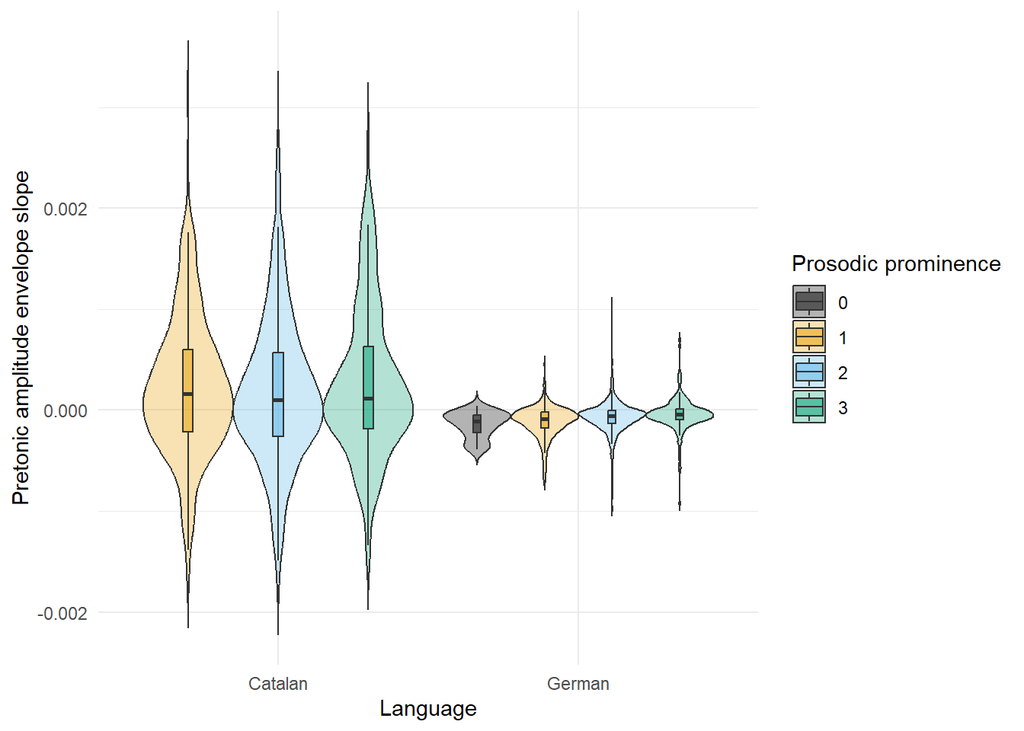

```r
# Plot
ggplot(data_prepost %>% filter(!is.na(percProm)), aes(x = language, y = env_slopePre, fill = as.factor(percProm))) +
  geom_violin(scale = "width", trim = FALSE, alpha = 0.3) +
  geom_boxplot(width = 0.1, outlier.shape = NA, position = position_dodge(width = 0.9), alpha = 0.5) +
  labs(
    x = "Language",
    y = "Pretonic amplitude envelope slope",
    fill = "Prosodic prominence"
  ) +
  scale_fill_manual(values = colorBlindBlack8) +
  theme_minimal()
```

```r
ggsave(filename = paste0(plots, "prominence_env_slope_pretonic.pdf"), plot = last_plot(), width = 6, height = 4)
```

#### 3.3.3.6 Pitch (median)

What is the average pitch (median) across the different prosodic prominence ratings in Catalan vs in German?

```r
#Vavlues
## Raw
avg_pitch_median_pre <- data_prepost %>%
  group_by(language, percProm) %>%
  summarize(avg_pitch_median = mean(pitch_medianPre, na.rm = TRUE))

## Normalized
data_prepost %>%
  group_by(language, percProm) %>%
  summarize(avg_pitch_median_norm = mean(pitch_median_normPre, na.rm = TRUE))
```

| language | percProm | avg_pitch_median_norm |
| --- | --- | --- |
| Catalan | 1 | -0.013339060 |
| Catalan | 2 | 0.118276069 |
| Catalan | 3 | 0.087281581 |
| German | 0 | -0.357141846 |
| German | 1 | 0.004132628 |
| German | 2 | 0.010334040 |
| German | 3 | -0.128157603 |

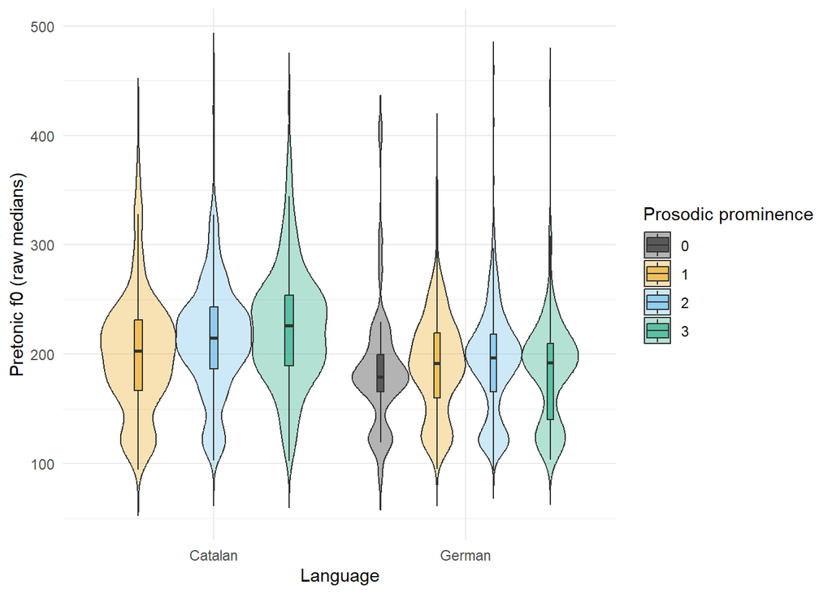

```r
# Plots
## Raw
ggplot(data_prepost %>% filter(!is.na(percProm)), aes(x = language, y = pitch_medianPre, fill = as.factor(percProm))) +
  geom_violin(scale = "width", trim = FALSE, alpha = 0.3) +
  geom_boxplot(width = 0.1, outlier.shape = NA, position = position_dodge(width = 0.9), alpha = 0.5) +
  labs(
    x = "Language",
    y = "Pretonic f0 (raw medians)",
    fill = "Prosodic prominence"
  ) +
  scale_fill_manual(values = colorBlindBlack8) +
  theme_minimal()
```

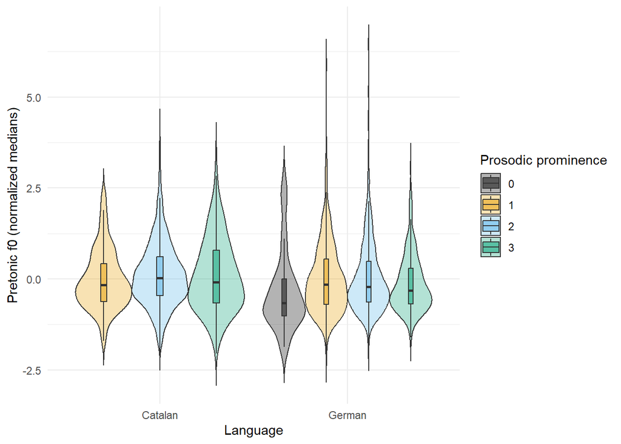

```r
ggsave(filename = paste0(plots, "prominence_pitch_median_raw_pretonic.pdf"), plot = last_plot(), width = 6, height = 4)

## Normalized
ggplot(data_prepost %>% filter(!is.na(percProm)), aes(x = language, y = pitch_median_normPre, fill = as.factor(percProm))) +
  geom_violin(scale = "width", trim = FALSE, alpha = 0.3) +
  geom_boxplot(width = 0.1, outlier.shape = NA, position = position_dodge(width = 0.9), alpha = 0.5) +
  labs(
    x = "Language",
    y = "Pretonic f0 (normalized medians)",
    fill = "Prosodic prominence"
  ) +
  scale_fill_manual(values = colorBlindBlack8) +
  theme_minimal()
```

```r
ggsave(filename = paste0(plots, "prominence_pitch_median_norm_pretonic.pdf"), plot = last_plot(), width = 6, height = 4)
```

#### 3.3.3.7 Pitch (sd)

What is the average pitch (sd) across the different prosodic prominence ratings in Catalan vs in German?

```r
# Values
## Raw
data_prepost %>%
  group_by(language, percProm) %>%
  summarize(avg_pitch_sd = mean(pitch_sdPre, na.rm = TRUE))
```

| language | percProm | avg_pitch_sd |
| --- | --- | --- |
| Catalan | 1 | 9.747865 |
| Catalan | 2 | 10.756565 |
| Catalan | 3 | 18.164816 |
| German | 0 | 10.529056 |
| German | 1 | 9.572890 |
| German | 2 | 9.535860 |
| German | 3 | 10.668083 |

```r
## Normalized
data_prepost %>%
  group_by(language, percProm) %>%
  summarize(avg_pitch_sd = mean(pitch_sd_normPre, na.rm = TRUE))
```

| language | percProm | avg_pitch_sd |
| --- | --- | --- |
| Catalan | 1 | -0.20856469 |
| Catalan | 2 | -0.13162313 |
| Catalan | 3 | 0.08010675 |
| German | 0 | -0.15386674 |
| German | 1 | -0.18309737 |
| German | 2 | -0.19616547 |
| German | 3 | -0.17437502 |

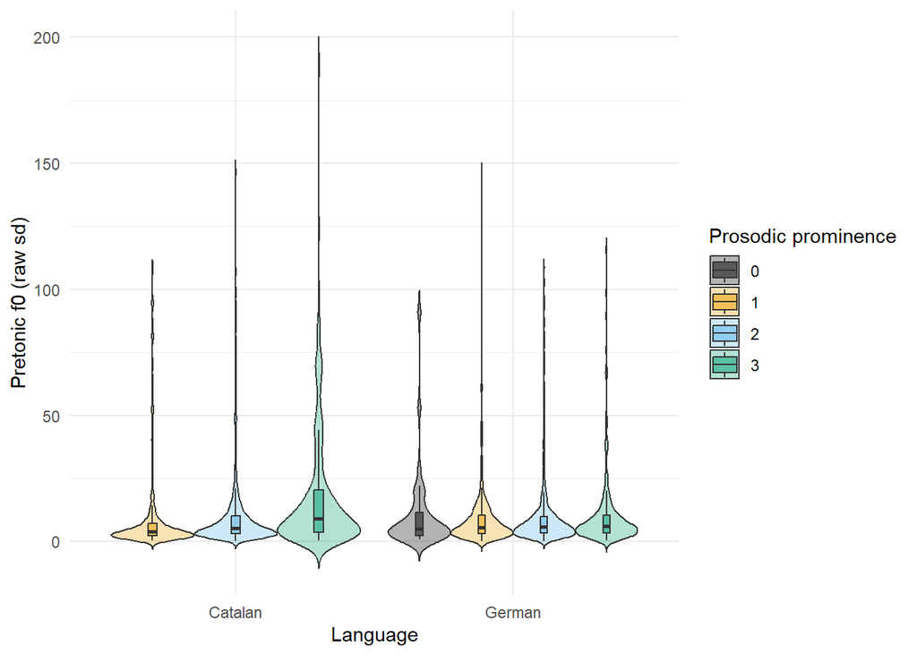

```r
# Plots
## Raw
ggplot(data_prepost %>% filter(!is.na(percProm)), aes(x = language, y = pitch_sdPre, fill = as.factor(percProm))) +
  geom_violin(scale = "width", trim = FALSE, alpha = 0.3) +
  geom_boxplot(width = 0.1, outlier.shape = NA, position = position_dodge(width = 0.9), alpha = 0.5) +
  labs(
    #title = "Duration of Prosodic Prominence Ratings by Language",
    x = "Language",
    y = "Pretonic f0 (raw sd)",
    fill = "Prosodic prominence"
  ) +
  scale_fill_manual(values = colorBlindBlack8) +
  theme_minimal()
```

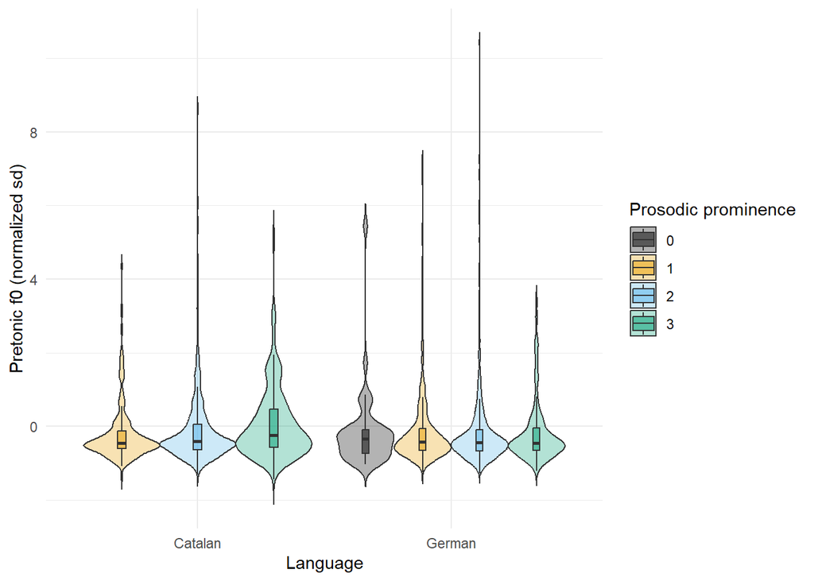

```r
ggsave(filename = paste0(plots, "prominence_pitch_sd_raw_pretonic.pdf"), plot = last_plot(), width = 6, height = 4)

## Normalized
ggplot(data_prepost %>% filter(!is.na(percProm)), aes(x = language, y = pitch_sd_normPre, fill = as.factor(percProm))) +
  geom_violin(scale = "width", trim = FALSE, alpha = 0.3) +
  geom_boxplot(width = 0.1, outlier.shape = NA, position = position_dodge(width = 0.9), alpha = 0.5) +
  labs(
    #title = "Duration of Prosodic Prominence Ratings by Language",
    x = "Language",
    y = "Pretonic f0 (normalized sd)",
    fill = "Prosodic prominence"
  ) +
  scale_fill_manual(values = colorBlindBlack8) +
  theme_minimal()
```

```r
ggsave(filename = paste0(plots, "prominence_pitch_sd_norm_pretonic.pdf"), plot = last_plot(), width = 6, height = 4)
```